# Dispositions and sentences of federal felony cases related to protests in the Summer and Fall of 2020

## Data

The [data for this report](https://docs.google.com/spreadsheets/d/1jSN5ueyn5UpgUwnjEIOJumQst7VIjuou6qrgHCNuhIM) are from two sources. The population of cases was identified using The Prosecution Project’s (tPP) [dataset of summer/fall 2020 protest-related felony cases](https://theprosecutionproject.org/summer-2020-protests/). This lists 1,458 cases, 363 of which are federal. This list is not comprehensive. The Prosecution Project occasionally adds cases to it.

The source for information on sentencing is [the Federal Judicial Center’s (FJC) Integrated Database (IDB)](https://www.fjc.gov/research/idb). The last update to the criminal defendants dataset was on March 31, 2022.

## Method

The 5 year snapshot for [Criminal defendants filed, terminated, and pending from FY 1996 to present](https://www.fjc.gov/research/idb/criminal-defendants-filed-terminated-and-pending-fy-1996-present) was downloaded and filtered to cases filed after January 1, 2020.

The docket number and FJC court identifier for each federal case was retrieved using a query of the [Court Listener API](https://www.courtlistener.com/api/rest-info/), based on the full legal names and case locations in the dataset from the Prosecution Project. The docket number, district court ID, and court office ID were combined to form a unique case identifier that matches the FJC data. The FJC variables related to charges, dispositions, and sentencing were merged to the population of federal cases, matching on this identifier.

## Summary

### Frequency of filing offenses

| Title | Frequency |
| --- | --- |
| 18:231.F | 62 |
| 18:922G.F | 48 |
| 18:844I.F | 47 |
| 18:844F.F | 32 |
| 18:371.F | 31 |
| 40:1315.P | 27 |
| 18:111A.M | 22 |
| 18:2101.F | 20 |
| 18:844N.F | 20 |
| 18:844A.F | 16 |
| 26:5861D.F | 15 |
| 18:1361.F | 14 |
| 18:844H.F | 13 |
| 18:111.F | 12 |
| 18:844E.F | 11 |
| 18:922A.F | 10 |
| 26:5861F.F | 10 |
| 18:2118B.F | 9 |
| 18:922U.F | 9 |
| 18:875C.F | 8 |
| 18:2113A.F | 7 |
| 18:924C.F | 7 |
| 26:5841.F | 7 |
| 18:1114.F | 6 |
| 18:13-9999.F | 6 |
| 18:1752.P | 6 |
| 18:844G.F | 6 |
| 18:922J.F | 6 |
| 18:2339A.F | 4 |
| 18:13-7990.M | 3 |
| 18:1361.M | 3 |
| 18:1951.F | 3 |
| 18:39A.F | 3 |
| 18:922C.F | 3 |
| 21:846=CD.F | 3 |
| 26:5861C.F | 3 |
| 18:115A1B.F | 2 |
| 18:13-7910.F | 2 |
| 18:201B.F | 2 |
| 18:2113B.F | 2 |
| 18:2339B.F | 2 |
| 18:641.F | 2 |
| 18:875A.F | 2 |
| 18:912.F | 2 |
| 18:922N.F | 2 |
| 18:922O.F | 2 |
| 18:924A.F | 2 |
| 18:924G.F | 2 |
| 18:924J1.F | 2 |
| 21:841A=CD.F | 2 |
| 49:46307.M | 2 |
| 18:1014.F | 1 |
| 18:1038.F | 1 |
| 18:113E.M | 1 |
| 18:115.F | 1 |
| 18:13-9993.F | 1 |
| 18:1343.F | 1 |
| 18:1512C.F | 1 |
| 18:2.F | 1 |
| 18:201A.F | 1 |
| 18:2119.F | 1 |
| 18:38.F | 1 |
| 18:875D.F | 1 |
| 18:879.F | 1 |
| 18:931.F | 1 |
| 21:844A=MP.M | 1 |
| 22DC:404.F | 1 |
| 26:5861A.F | 1 |
| 49:46506.M | 1 |

### Dispositions

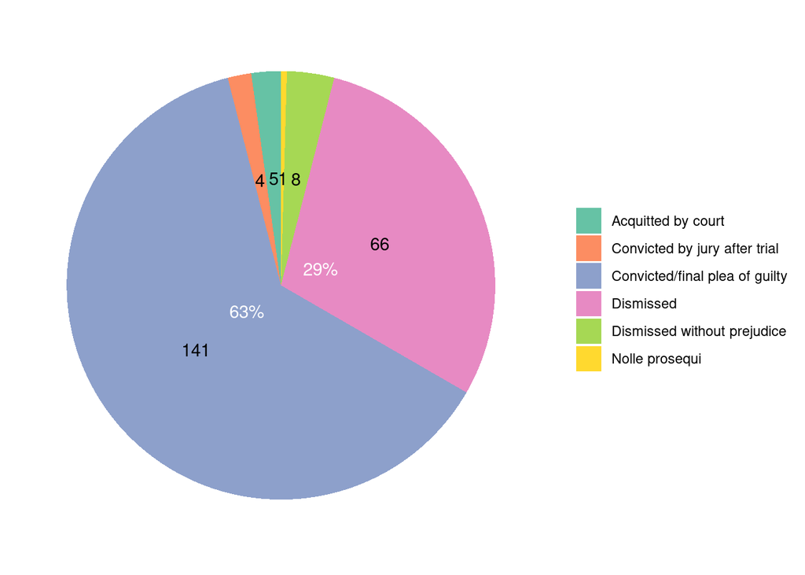

### Sentences

152 cases have a recorded Sentencing Date. 132 of those have a non-missing value for total prison time (including 0). 90% of those 132 defendants received 69 months or less. 25 of them received no prison time. The longest sentence so far is 11 years and 7 months.

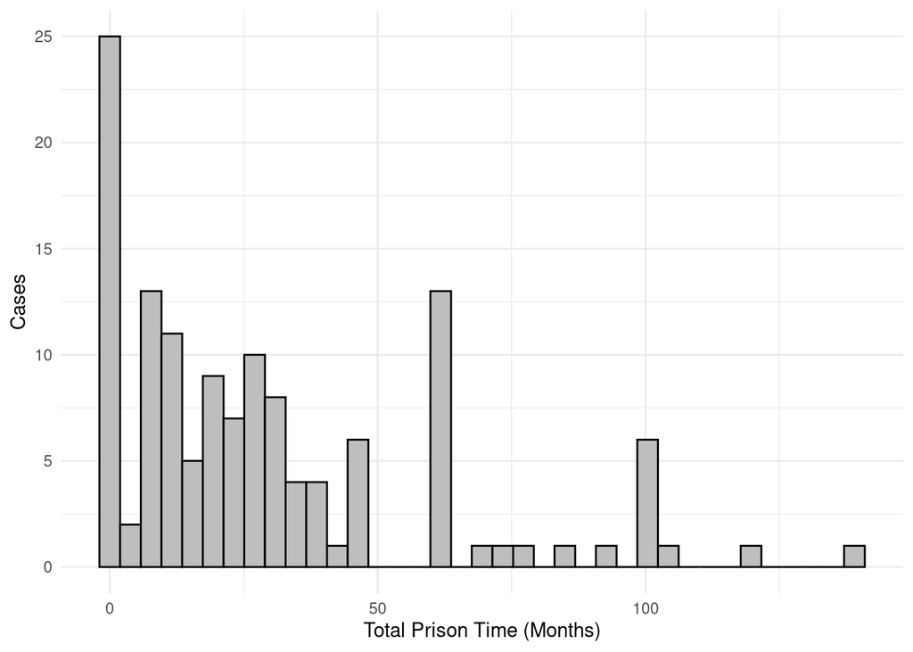

### Subsets

Only 5 defendants received a prison sentence that is longer than the lower end of the maximum possible sentence range for their most serious charge. Here are those cases.

| Name | Docket | State | Prison Time (Months) | Guidelines Lower Bound | Guidelines Upper Bound |
| --- | --- | --- | --- | --- | --- |
| Courtland Renford | 1:20-cr-00080 | New York | 60 | 48 | 60 |
| Demonte Tretion Kelly | 3:20-cr-00300 | Texas | 100 | 72 | 120 |
| Lejael Justus Rudley | 3:20-cr-00300 | Texas | 100 | 72 | 120 |
| Erick Montgomery | 3:20-cr-00300 | Texas | 100 | 72 | 120 |
| James Patrick Giannakos Jr. | 3:21-cr-00126 | South Carolina | 28 | 12 | 24 |

The following 86 cases have not reached a disposition. They are arranged by filing date (oldest to newest).

| Name | Docket | State | Filing Date | Filing Offenses |
| --- | --- | --- | --- | --- |
| Deyanna Davis | 1:20-cr-00079 | New York | 06/04/2020 | 18:922G.F, 18:922G.F |
| Semaj Pigram | 1:20-cr-00079 | New York | 06/04/2020 | 18:922G.F, 18:922G.F |
| Walter Stewart | 1:20-cr-00079 | New York | 06/04/2020 | 18:922G.F, 18:922G.F |
| Melquan Barnett | 1:20-cr-00018 | Pennsylvania | 06/09/2020 | 18:844A.F |
| Amber L. Peltzer | 1:20-cr-00257 | Illinois | 06/10/2020 | 18:922G.F |
| Joseph Hammond | 1:20-cr-00263 | Illinois | 06/10/2020 | 18:924C.F, 18:922G.F, 18:922G.F, 18:111.F, 18:111.F |
| Colinford Mattis | 1:20-cr-00203 | New York | 06/11/2020 | 18:844H.F, 18:844H.F, 18:924G.F, 26:5861F.F, 18:231.F |
| Urooj Rahman | 1:20-cr-00203 | New York | 06/11/2020 | 18:844H.F, 18:844H.F, 18:924G.F, 26:5861F.F, 18:231.F |
| Ca’Quintez Gibson | 1:20-cr-10041 | Illinois | 06/16/2020 | 18:2101.F |
| Tyree Walker | 2:20-cr-00126 | Nevada | 06/16/2020 | 18:844F.F, 18:844I.F, 18:844N.F, 18:844N.F, 18:231.F |
| Devarian Haynes | 2:20-cr-00126 | Nevada | 06/16/2020 | 18:844F.F, 18:844I.F, 18:844N.F, 18:844N.F, 18:231.F |
| Ricardo Densmore | 2:20-cr-00126 | Nevada | 06/16/2020 | 18:844F.F, 18:844I.F, 18:844N.F, 18:844N.F, 18:231.F |
| Stephen T. Parshall | 2:20-cr-00128 | Nevada | 06/17/2020 | 18:844F.F, 26:5841.F |
| Andrew Lynam | 2:20-cr-00128 | Nevada | 06/17/2020 | 18:844F.F, 26:5841.F |
| William L. Loomis | 2:20-cr-00128 | Nevada | 06/17/2020 | 18:844F.F, 26:5841.F |
| Jeremiah J. Scott | 1:20-cr-00267 | Illinois | 06/24/2020 | 18:922G.F |
| Kevin D. Tunstall | 1:20-cr-00259 | Illinois | 06/24/2020 | 18:922G.F |
| Charles Anthony Pittman | 5:20-cr-00305 | North Carolina | 06/24/2020 | 18:844E.F, 18:844E.F, 18:844E.F, 18:2101.F, 18:2101.F |
| Steven Carrillo | 4:20-cr-00265 | California | 06/25/2020 | 18:1114.F, 18:1114.F, 18:1114.F, 18:924J1.F |
| Robert Alvin Justus Jr. | 4:20-cr-00265 | California | 06/25/2020 | 18:1114.F, 18:1114.F, 18:1114.F, 18:924J1.F |
| Adrian Oscar Duran | 2:20-cr-00105 | California | 06/25/2020 | 18:922U.F, 18:922J.F |
| Donley Thompson | 2:20-cr-00105 | California | 06/25/2020 | 18:922U.F, 18:922J.F |
| Donte Marcel Anderson | 2:20-cr-00105 | California | 06/25/2020 | 18:922U.F, 18:922J.F |
| Tracy Whitfield | 2:20-cr-00105 | California | 06/25/2020 | 18:922U.F, 18:922J.F |
| Desteny Estrella Leilani Salazar | 2:20-cr-00105 | California | 06/25/2020 | 18:922U.F, 18:922J.F |
| Timothy James Goodner (2) | 1:20-cr-00346 | Ohio | 07/01/2020 | 18:844I.F, 18:371.F |
| Micah Tillmon (1) | 2:20-cr-00289 | California | 07/14/2020 | 18:844I.F, 26:5861D.F |
| Micah Eugene Avery Jr. | 1:20-cr-00109 | District of Columbia | 07/14/2020 | 18:1361.F |
| Devinare Antwan Parker | 2:20-cr-00084 | Washington | 07/22/2020 | 26:5861D.F |
| Nicholas Lucia (1) | 2:20-cr-00174 | Pennsylvania | 07/22/2020 | 18:231.F |

[output cut: 56 more lines]